# heart_data-decision_tree

```python
""" Please install the following libraries before running the code """

# pip install numpy
# pip install pandas
# pip install seaborn
# pip install matplotlib
# pip install scikit-learn
```

```
' Please install the following libraries before running the code '
```

### Importing required packages

```python
import pandas as pd
import numpy as np
import seaborn as sns
import matplotlib.pyplot as plt
from sklearn.preprocessing import LabelEncoder
from sklearn.impute import SimpleImputer
from sklearn.model_selection import train_test_split
from sklearn.naive_bayes import GaussianNB
from sklearn import tree
from sklearn.metrics import (accuracy_score, confusion_matrix, ConfusionMatrixDisplay, f1_score)

from six import StringIO
import pydotplus
from sklearn.model_selection import GridSearchCV
import pickle
```

### Read dataset from memory

```python
# First 10 rows of the data
raw_data = pd.read_csv('US_Heart_Patients.csv')
raw_data.head(10)
```

|  | Gender | age | education | currentSmoker | cigsPerDay | BP Meds | prevalentStroke | prevalentHyp | diabetes | tot cholesterol | Systolic BP | Diastolic BP | BMI | heartRate | glucose | Heart-Att |
| --- | --- | --- | --- | --- | --- | --- | --- | --- | --- | --- | --- | --- | --- | --- | --- | --- |
| 0 | Male | 39.0 | 4.0 | 0.0 | 0.0 | 0.0 | 0.0 | 0.0 | 0.0 | 195.0 | 106.0 | 70.0 | 26.97 | 80.0 | 77.0 | 0 |
| 1 | Female | 46.0 | 2.0 | 0.0 | 0.0 | 0.0 | 0.0 | 0.0 | 0.0 | 250.0 | 121.0 | 81.0 | 28.73 | 95.0 | 76.0 | 0 |
| 2 | Male | 48.0 | 1.0 | 1.0 | 20.0 | 0.0 | 0.0 | 0.0 | 0.0 | 245.0 | 127.5 | 80.0 | 25.34 | 75.0 | 70.0 | 0 |
| 3 | Female | 61.0 | 3.0 | 1.0 | 30.0 | 0.0 | 0.0 | 1.0 | 0.0 | 225.0 | 150.0 | 95.0 | 28.58 | 65.0 | 103.0 | 1 |
| 4 | Female | 46.0 | 3.0 | 1.0 | 23.0 | 0.0 | 0.0 | 0.0 | 0.0 | 285.0 | 130.0 | 84.0 | 23.10 | 85.0 | 85.0 | 0 |
| 5 | Female | 43.0 | 2.0 | 0.0 | 0.0 | 0.0 | 0.0 | 1.0 | 0.0 | 228.0 | 180.0 | 110.0 | 30.30 | 77.0 | 99.0 | 0 |
| 6 | Female | 63.0 | 1.0 | 0.0 | 0.0 | 0.0 | 0.0 | 0.0 | 0.0 | 205.0 | 138.0 | 71.0 | 33.11 | 60.0 | 85.0 | 1 |
| 7 | Female | 45.0 | 2.0 | 1.0 | 20.0 | 0.0 | 0.0 | 0.0 | 0.0 | 313.0 | 100.0 | 71.0 | 21.68 | 79.0 | 78.0 | 0 |
| 8 | Male | 52.0 | 1.0 | 0.0 | 0.0 | 0.0 | 0.0 | 1.0 | 0.0 | 260.0 | 141.5 | 89.0 | 26.36 | 76.0 | 79.0 | 0 |
| 9 | Male | 43.0 | 1.0 | 1.0 | 30.0 | 0.0 | 0.0 | 1.0 | 0.0 | 225.0 | 162.0 | 107.0 | 23.61 | 93.0 | 88.0 | 0 |

### Information about the column (data types)

```python
raw_data.info()
```

```
<class 'pandas.core.frame.DataFrame'>
RangeIndex: 4240 entries, 0 to 4239
Data columns (total 16 columns):
 #   Column           Non-Null Count  Dtype
---  ------           --------------  -----
 0   Gender           4232 non-null   object
 1   age              4238 non-null   float64
 2   education        4130 non-null   float64
 3   currentSmoker    4237 non-null   float64
 4   cigsPerDay       4209 non-null   float64
 5   BP Meds          4180 non-null   float64
 6   prevalentStroke  4231 non-null   float64
 7   prevalentHyp     4238 non-null   float64
 8   diabetes         4238 non-null   float64
 9   tot cholesterol  4180 non-null   float64
 10  Systolic BP      4236 non-null   float64
 11  Diastolic BP     4235 non-null   float64
 12  BMI              4216 non-null   float64
 13  heartRate        4236 non-null   float64
 14  glucose          3849 non-null   float64
 15  Heart-Att        4240 non-null   int64
dtypes: float64(14), int64(1), object(1)
memory usage: 530.1+ KB
```

### Find missing value in data

```python
def missing_data_percentage(df):
    # To find the percentage of missing values in each column
    # find data blank or NA use isnull() and replace with mean (in this case mean count missing value and devide by total count)
    # after that multiply by 100 to get percentage
    # missing_values = (count_missing_value/total_count)*100
    missing_values = df.isnull().mean()
    print('Percentage of missing values in each column is:')
    print(missing_values.map(lambda x: round(x * 100,2)))

missing_data_percentage(raw_data)
```

```
Percentage of missing values in each column is:
Gender             0.19
age                0.05
education          2.59
currentSmoker      0.07
cigsPerDay         0.73
BP Meds            1.42
prevalentStroke    0.21
prevalentHyp       0.05
diabetes           0.05
tot cholesterol    1.42
Systolic BP        0.09
Diastolic BP       0.12
BMI                0.57
heartRate          0.09
glucose            9.22
Heart-Att          0.00
dtype: float64
```

as we can see accept Heart-Att all have missing value. But no column have more than 25% value missing. So we will remove any column, Instead impute(replace) missing values

### Impute the missing values

There are three ways to impute missing value in dataset which are following:

1. Mean: As we have some columns like ‘BP Meds’, ‘prevalentStroke’, ‘prevalentHyp’, ‘diabetes’ data in Boolean form (0,1) so can directly apply mean method.
2. Median: Our data is not in sorted form and nature we can’t use median method also.
3. Mode: Let us use most-frequent value as because have less missing value on base of column it is between (0.05% to 2.59%) accept(only one column glucose (9.22%))

```python
# For filling missing values in the data we use SimpleImputer from sklearn.impute
imp = SimpleImputer(missing_values=np.nan, strategy="most_frequent")
# give training data to imputer
imp.fit(raw_data)
# Resulted data after filling missing values
imp_data = pd.DataFrame(imp.transform(raw_data), columns=raw_data.columns)
missing_data_percentage(imp_data)
```

```
Percentage of missing values in each column is:
Gender             0.0
age                0.0
education          0.0
currentSmoker      0.0
cigsPerDay         0.0
BP Meds            0.0
prevalentStroke    0.0
prevalentHyp       0.0
diabetes           0.0
tot cholesterol    0.0
Systolic BP        0.0
Diastolic BP       0.0
BMI                0.0
heartRate          0.0
glucose            0.0
Heart-Att          0.0
dtype: float64
```

No blank or null present in dataset

### Encode data to process in ML model

```python
print('Unique values in each column:')
# other columns have numeric values which can vary too much so we will not print them
for col in imp_data[['Gender', 'education', 'currentSmoker', 'BP Meds', 'prevalentStroke', 'prevalentHyp', 'diabetes', 'Heart-Att']].columns:
    print(col, ':', imp_data[col].unique())
```

```
Unique values in each column:
Gender : ['Male' 'Female']
education : [4.0 2.0 1.0 3.0]
currentSmoker : [0.0 1.0]
BP Meds : [0.0 1.0]
prevalentStroke : [0.0 1.0]
prevalentHyp : [0.0 1.0]
diabetes : [0.0 1.0]
Heart-Att : [0 1]
```

As we can see Gender column have string value (Male, Female) which not best for model training let encode it.

```python
# Copy data imputed data
encoded_data = imp_data.copy()
# Convert data type from Object to its respesctive data type.
encoded_data = encoded_data.convert_dtypes()


# create label encoder object
le = LabelEncoder()
# encode data
encoded_data['Gender'] = le.fit_transform(encoded_data['Gender'])

encoded_data.head()
```

|  | Gender | age | education | currentSmoker | cigsPerDay | BP Meds | prevalentStroke | prevalentHyp | diabetes | tot cholesterol | Systolic BP | Diastolic BP | BMI | heartRate | glucose | Heart-Att |
| --- | --- | --- | --- | --- | --- | --- | --- | --- | --- | --- | --- | --- | --- | --- | --- | --- |
| 0 | 1 | 39 | 4 | 0 | 0 | 0 | 0 | 0 | 0 | 195 | 106.0 | 70.0 | 26.97 | 80 | 77 | 0 |
| 1 | 0 | 46 | 2 | 0 | 0 | 0 | 0 | 0 | 0 | 250 | 121.0 | 81.0 | 28.73 | 95 | 76 | 0 |
| 2 | 1 | 48 | 1 | 1 | 20 | 0 | 0 | 0 | 0 | 245 | 127.5 | 80.0 | 25.34 | 75 | 70 | 0 |
| 3 | 0 | 61 | 3 | 1 | 30 | 0 | 0 | 1 | 0 | 225 | 150.0 | 95.0 | 28.58 | 65 | 103 | 1 |
| 4 | 0 | 46 | 3 | 1 | 23 | 0 | 0 | 0 | 0 | 285 | 130.0 | 84.0 | 23.1 | 85 | 85 | 0 |

```python
encoded_data.info()
```

```
<class 'pandas.core.frame.DataFrame'>
RangeIndex: 4240 entries, 0 to 4239
Data columns (total 16 columns):
 #   Column           Non-Null Count  Dtype
---  ------           --------------  -----
 0   Gender           4240 non-null   int32
 1   age              4240 non-null   Int64
 2   education        4240 non-null   Int64
 3   currentSmoker    4240 non-null   Int64
 4   cigsPerDay       4240 non-null   Int64
 5   BP Meds          4240 non-null   Int64
 6   prevalentStroke  4240 non-null   Int64
 7   prevalentHyp     4240 non-null   Int64
 8   diabetes         4240 non-null   Int64
 9   tot cholesterol  4240 non-null   Int64
 10  Systolic BP      4240 non-null   Float64
 11  Diastolic BP     4240 non-null   Float64
 12  BMI              4240 non-null   Float64
 13  heartRate        4240 non-null   Int64
 14  glucose          4240 non-null   Int64
 15  Heart-Att        4240 non-null   Int64
dtypes: Float64(3), Int64(12), int32(1)
memory usage: 575.7 KB
```

### 5-point summary

```python
encoded_data.describe().loc[['min', '25%', '50%', '75%', 'max']].T
```

|  | min | 25% | 50% | 75% | max |
| --- | --- | --- | --- | --- | --- |
| Gender | 0.0 | 0.0 | 0.0 | 1.0 | 1.0 |
| age | 32.0 | 42.0 | 49.0 | 56.0 | 70.0 |
| education | 1.0 | 1.0 | 2.0 | 3.0 | 4.0 |
| currentSmoker | 0.0 | 0.0 | 0.0 | 1.0 | 1.0 |
| cigsPerDay | 0.0 | 0.0 | 0.0 | 20.0 | 70.0 |
| BP Meds | 0.0 | 0.0 | 0.0 | 0.0 | 1.0 |
| prevalentStroke | 0.0 | 0.0 | 0.0 | 0.0 | 1.0 |
| prevalentHyp | 0.0 | 0.0 | 0.0 | 1.0 | 1.0 |
| diabetes | 0.0 | 0.0 | 0.0 | 0.0 | 1.0 |
| tot cholesterol | 107.0 | 206.0 | 234.0 | 262.0 | 696.0 |
| Systolic BP | 83.5 | 117.0 | 128.0 | 144.0 | 295.0 |
| Diastolic BP | 48.0 | 75.0 | 82.0 | 89.625 | 142.5 |
| BMI | 15.54 | 23.0375 | 25.375 | 28.02 | 56.8 |
| heartRate | 44.0 | 68.0 | 75.0 | 83.0 | 143.0 |
| glucose | 40.0 | 72.0 | 77.0 | 85.0 | 394.0 |
| Heart-Att | 0.0 | 0.0 | 0.0 | 0.0 | 1.0 |

### Find outliers and show with graph

```python
data_outliers = encoded_data.copy();
```

```python
def find_outliers_IQR(df):
   q1=df.quantile(0.25)
   q3=df.quantile(0.75)
   IQR=q3-q1
   outliers = df[((df<(q1-1.5*IQR)) | (df>(q3+1.5*IQR)))]
   return outliers

def zscore_outliers(df):
   col_name = f'ZScore_{df.name}'
   mean = np.mean(df)
   std = np.std(df)
   data_outliers[col_name] = (df - mean)/std
   outliers_zscore = df[abs(data_outliers[col_name]) >3]
   data_outliers.drop(columns=[col_name], axis=1, inplace=True)
   return outliers_zscore

def print_outliers(df):
   iqr = find_outliers_IQR(df)
   zscore = zscore_outliers(df)
   print('-----------------Outliers-----------------')
   print(f'{df.name} outliers: ')
   print(f'Number of outliers| IQR: {len(iqr)} \t ZS: {len(zscore)}')
   print(f'Max outlier value | IQR: {iqr.max()} \t ZS: {zscore.max()}')
   print(f'min outlier value | IQR: {iqr.min()} \t ZS: {zscore.min()}')
   print('------------------------------------------')

for col in data_outliers[encoded_data.columns].columns:
   print_outliers(data_outliers[col])

data_outliers.head()
```

```
-----------------Outliers-----------------
Gender outliers:
Number of outliers| IQR: 0 	 ZS: 0
Max outlier value | IQR: nan 	 ZS: nan
min outlier value | IQR: nan 	 ZS: nan
------------------------------------------
-----------------Outliers-----------------
age outliers:
Number of outliers| IQR: 0 	 ZS: 0
Max outlier value | IQR: <NA> 	 ZS: <NA>
min outlier value | IQR: <NA> 	 ZS: <NA>
------------------------------------------
-----------------Outliers-----------------
education outliers:
Number of outliers| IQR: 0 	 ZS: 0
Max outlier value | IQR: <NA> 	 ZS: <NA>
min outlier value | IQR: <NA> 	 ZS: <NA>
------------------------------------------
-----------------Outliers-----------------
currentSmoker outliers:
Number of outliers| IQR: 0 	 ZS: 0
Max outlier value | IQR: <NA> 	 ZS: <NA>
min outlier value | IQR: <NA> 	 ZS: <NA>
------------------------------------------
-----------------Outliers-----------------
cigsPerDay outliers:
Number of outliers| IQR: 12 	 ZS: 21
Max outlier value | IQR: 70 	 ZS: 70
min outlier value | IQR: 60 	 ZS: 45
------------------------------------------
-----------------Outliers-----------------
BP Meds outliers:
Number of outliers| IQR: 124 	 ZS: 124
Max outlier value | IQR: 1 	 ZS: 1
min outlier value | IQR: 1 	 ZS: 1
------------------------------------------
-----------------Outliers-----------------
prevalentStroke outliers:
Number of outliers| IQR: 25 	 ZS: 25
Max outlier value | IQR: 1 	 ZS: 1
```

[output cut: 41 more lines]

```
Max outlier value | IQR: 143 	 ZS: 143
min outlier value | IQR: 44 	 ZS: 112
------------------------------------------
-----------------Outliers-----------------
glucose outliers:
Number of outliers| IQR: 261 	 ZS: 50
Max outlier value | IQR: 394 	 ZS: 394
min outlier value | IQR: 40 	 ZS: 155
------------------------------------------
-----------------Outliers-----------------
Heart-Att outliers:
Number of outliers| IQR: 644 	 ZS: 0
Max outlier value | IQR: 1 	 ZS: <NA>
min outlier value | IQR: 1 	 ZS: <NA>
------------------------------------------
```

|  | Gender | age | education | currentSmoker | cigsPerDay | BP Meds | prevalentStroke | prevalentHyp | diabetes | tot cholesterol | Systolic BP | Diastolic BP | BMI | heartRate | glucose | Heart-Att |
| --- | --- | --- | --- | --- | --- | --- | --- | --- | --- | --- | --- | --- | --- | --- | --- | --- |
| 0 | 1 | 39 | 4 | 0 | 0 | 0 | 0 | 0 | 0 | 195 | 106.0 | 70.0 | 26.97 | 80 | 77 | 0 |
| 1 | 0 | 46 | 2 | 0 | 0 | 0 | 0 | 0 | 0 | 250 | 121.0 | 81.0 | 28.73 | 95 | 76 | 0 |
| 2 | 1 | 48 | 1 | 1 | 20 | 0 | 0 | 0 | 0 | 245 | 127.5 | 80.0 | 25.34 | 75 | 70 | 0 |
| 3 | 0 | 61 | 3 | 1 | 30 | 0 | 0 | 1 | 0 | 225 | 150.0 | 95.0 | 28.58 | 65 | 103 | 1 |
| 4 | 0 | 46 | 3 | 1 | 23 | 0 | 0 | 0 | 0 | 285 | 130.0 | 84.0 | 23.1 | 85 | 85 | 0 |

As result of IQR and Z-Score 'cigsPerDay', 'tot cholesterol', 'Systolic BP', 'Diastolic BP', 'BMI', 'heartRate' and 'glucose' have outliers.

```python
#Show out outliers with boxplot
col_outliers = ['cigsPerDay', 'tot cholesterol', 'Systolic BP', 'Diastolic BP', 'BMI', 'heartRate', 'glucose']
plt.figure(figsize=(15,8))
sns.boxplot(data=encoded_data[col_outliers])
```

[output not shown]

### Data correlation & Distribution

```
                   Gender       age  education  currentSmoker  cigsPerDay  \
Gender           1.000000 -0.029237   0.014390       0.196498    0.313845
age             -0.029237  1.000000  -0.165296      -0.212555   -0.191372
education        0.014390 -0.165296   1.000000       0.019137    0.010832
currentSmoker    0.196498 -0.212555   0.019137       1.000000    0.759379
cigsPerDay       0.313845 -0.191372   0.010832       0.759379    1.000000
BP Meds         -0.051385  0.121115  -0.010109      -0.048266   -0.044588
prevalentStroke -0.004478  0.057724  -0.032854      -0.032944   -0.032203
prevalentHyp     0.006936  0.305582  -0.077630      -0.103932   -0.066007
diabetes         0.015850  0.101412  -0.038099      -0.044209   -0.036069
tot cholesterol -0.070143  0.260477  -0.023207      -0.045907   -0.026482
Systolic BP     -0.034906  0.393851  -0.125009      -0.130653   -0.088629
Diastolic BP     0.059661  0.205082  -0.061791      -0.108574   -0.057150
BMI              0.084173  0.132916  -0.137516      -0.164934   -0.091515
heartRate       -0.116241 -0.011654  -0.051145       0.061267    0.072906
glucose          0.014078  0.117284  -0.034979      -0.055320   -0.056212
Heart-Att        0.088789  0.225434  -0.052703       0.018334    0.059038

                  BP Meds  prevalentStroke  prevalentHyp  diabetes  \
Gender          -0.051385        -0.004478      0.006936  0.015850
age              0.121115         0.057724      0.305582  0.101412
education       -0.010109        -0.032854     -0.077630 -0.038099
currentSmoker   -0.048266        -0.032944     -0.103932 -0.044209
cigsPerDay      -0.044588        -0.032203     -0.066007 -0.036069
BP Meds          1.000000         0.114614      0.258722  0.051407
prevalentStroke  0.114614         1.000000      0.074846  0.006955
prevalentHyp     0.258722         0.074846      1.000000  0.077851
diabetes         0.051407         0.006955      0.077851  1.000000
tot cholesterol  0.078722         0.000062      0.163144  0.039331
Systolic BP      0.251523         0.057017      0.695820  0.111705
Diastolic BP     0.192284         0.045159      0.614814  0.050762
BMI              0.099341         0.019803      0.299339  0.084486
heartRate        0.015348        -0.017641      0.147422  0.049271
glucose          0.049389         0.019257      0.083365  0.606319
Heart-Att        0.086448         0.061823      0.176290  0.097344

                 tot cholesterol  Systolic BP  Diastolic BP       BMI  \
Gender                 -0.070143    -0.034906      0.059661  0.084173
age                     0.260477     0.393851      0.205082  0.132916
education              -0.023207    -0.125009     -0.061791 -0.137516
```

[output cut: 16 more lines]

```
age              -0.011654  0.117284   0.225434
education        -0.051145 -0.034979  -0.052703
currentSmoker     0.061267 -0.055320   0.018334
cigsPerDay        0.072906 -0.056212   0.059038
BP Meds           0.015348  0.049389   0.086448
prevalentStroke  -0.017641  0.019257   0.061823
prevalentHyp      0.147422  0.083365   0.176290
diabetes          0.049271  0.606319   0.097344
tot cholesterol   0.091117  0.045971   0.081912
Systolic BP       0.183277  0.134947   0.216460
Diastolic BP      0.181556  0.058393   0.144565
BMI               0.067550  0.080945   0.068628
heartRate         1.000000  0.085200   0.023872
glucose           0.085200  1.000000   0.120478
Heart-Att         0.023872  0.120478   1.000000
```

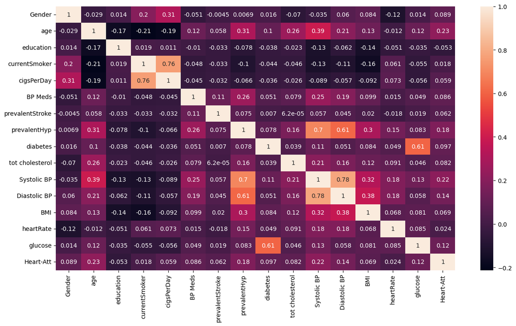

```python
# Check Correlation of the data
print(encoded_data.corr())
# plot heatmap
plt.figure(figsize=(15,8))
sns.heatmap(encoded_data.corr(), annot=True)
```

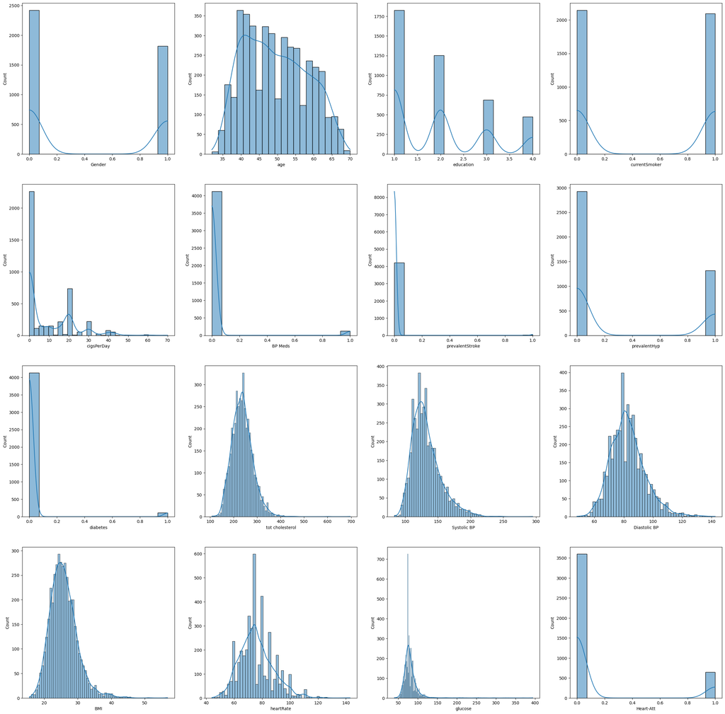

```python
fig, axes = plt.subplots(nrows=4,ncols=4, figsize=(30,30))
for i in range(4):
    for j in range(4):
        col_name = encoded_data.columns.values[i*4+j]
        sns.histplot(encoded_data[col_name], ax=axes[i][j], kde=True)

plt.show()
```

## Outlier treatment

we have two approch to treatment outlier which are:

1. IRQ Drop
2. Z-score Drop

```python
# funtion to drop outliers using IQR
def drop_outliers_IQR(df):
   q1=df.quantile(0.25)
   q3=df.quantile(0.75)
   IQR=q3-q1
   return df[~((df<(q1-1.5*IQR)) | (df>(q3+1.5*IQR)))]

def after_drop_outliers_IQR(df, col):
   not_outliers = drop_outliers_IQR(df[col])
   return df[ df[col].isin(not_outliers) ]

def after_drop_outliers_ZScore(data_frame, col):
   df_col = data_frame[col]
   col_name = f'ZScore_{df_col.name}'
   mean = np.mean(df_col)
   std = np.std(df_col)
   data_frame[col_name] = (df_col - mean)/std
   not_outliers = df_col[abs(data_frame[col_name]) <=3]
   result = data_frame[data_frame[col].isin(not_outliers)].copy()
   result.drop(columns=[col_name], axis=1, inplace=True)
   return result
```

### IRQ Drop Treatment

```
Data count after droping outliers: 3637
Droped record count: 603
```

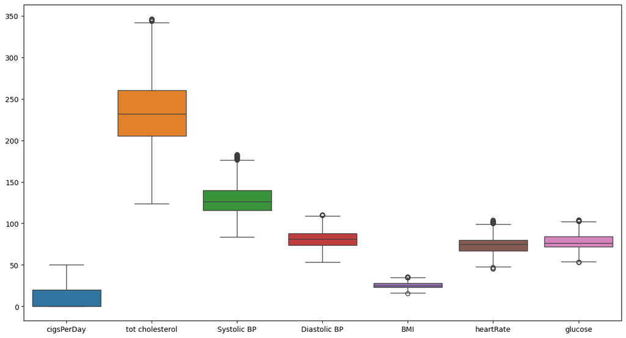

```python
iqr_outliers_dataSet = encoded_data.copy()

for col in col_outliers:
   iqr_outliers_dataSet = after_drop_outliers_IQR(iqr_outliers_dataSet, col)

print('Data count after droping outliers:', len(iqr_outliers_dataSet))
print('Droped record count:', len(encoded_data)-len(iqr_outliers_dataSet))

# Before droping outliers
plt.figure(figsize=(15,8))
sns.boxplot(data=encoded_data[col_outliers])
plt.show()
# After droping outliers with IQR
plt.figure(figsize=(15,8))
sns.boxplot(data=iqr_outliers_dataSet[col_outliers])
plt.show()
```

### Z-Score Treatment

```
Data count after droping outliers: 4001
Droped record count: 239
```

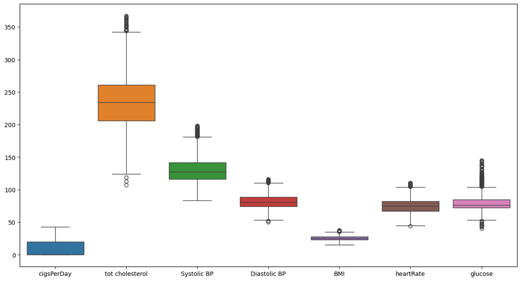

```python
zc_outliers_dataSet = encoded_data.copy()

for col in col_outliers:
   zc_outliers_dataSet = after_drop_outliers_ZScore(zc_outliers_dataSet, col)

print('Data count after droping outliers:', len(zc_outliers_dataSet))
print('Droped record count:', len(encoded_data)-len(zc_outliers_dataSet))

# Before droping outliers
plt.figure(figsize=(15,8))
sns.boxplot(data=encoded_data[col_outliers])
plt.show()
# After droping outliers with ZScore
plt.figure(figsize=(15,8))
sns.boxplot(data=zc_outliers_dataSet[col_outliers])
plt.show()
```

## Model preparation and evaluation

```python
def evaluate_model(model, X_train, y_train, X_test, y_test):
    fig, ax = plt.subplots(ncols=2, figsize=(20,5))
    print("-"*50)

    print("Train Accuracy :", accuracy_score(y_train, model.predict(X_train)))
    print("Train F1 Score:", f1_score(model.predict(X_train), y_train, average="weighted"))
    cm_train = confusion_matrix(y_train, model.predict(X_train))
    ax[0].set_title('Train Confusion Matrix')
    ConfusionMatrixDisplay(confusion_matrix=cm_train, display_labels=['No Heart-Att', 'Heart-Att']).plot(ax=ax[0])

    print("-"*50)

    print("Test Accuracy :", accuracy_score(y_test, model.predict(X_test)))
    print("Test F1 Score:", f1_score(model.predict(X_test), y_test, average="weighted"))
    print("Confusion Matrix:")

    cm_test = confusion_matrix(y_test, model.predict(X_test))
    ax[1].set_title('Test Confusion Matrix')
    ConfusionMatrixDisplay(confusion_matrix=cm_test, display_labels=['No Heart-Att', 'Heart-Att']).plot(ax=ax[1])
    plt.show()
```

### Naive Bayes Model

```python
def gaussian_nb_model(df):
    X = df.drop(columns=['Heart-Att'])
    y = df['Heart-Att']

    X_train, X_test, y_train, y_test = train_test_split(X, y, test_size=0.2, random_state=42)
    model = GaussianNB()
    model.fit(X_train, y_train)

    return [model, X_train, y_train, X_test, y_test]
```

```
With IQR outliers drop data
--------------------------------------------------
Train Accuracy : 0.5225163286352699
Train F1 Score: 0.4530175902730259
--------------------------------------------------
Test Accuracy : 0.510989010989011
Test F1 Score: 0.44158689116672317
Confusion Matrix:
```

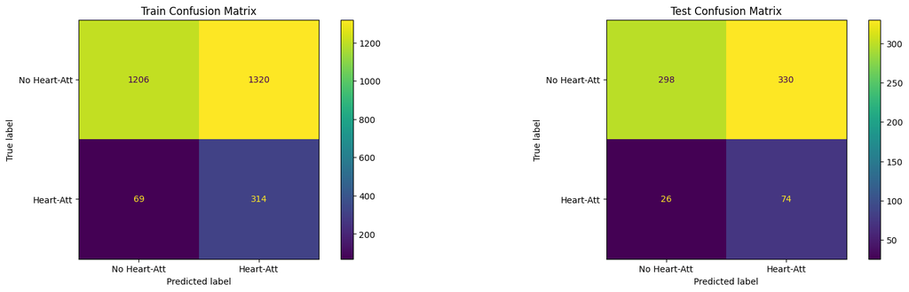

```
With ZScore outliers drop data
--------------------------------------------------
Train Accuracy : 0.835
Train F1 Score: 0.8587046138021186
--------------------------------------------------
Test Accuracy : 0.8339575530586767
Test F1 Score: 0.8570533829825538
Confusion Matrix:
```

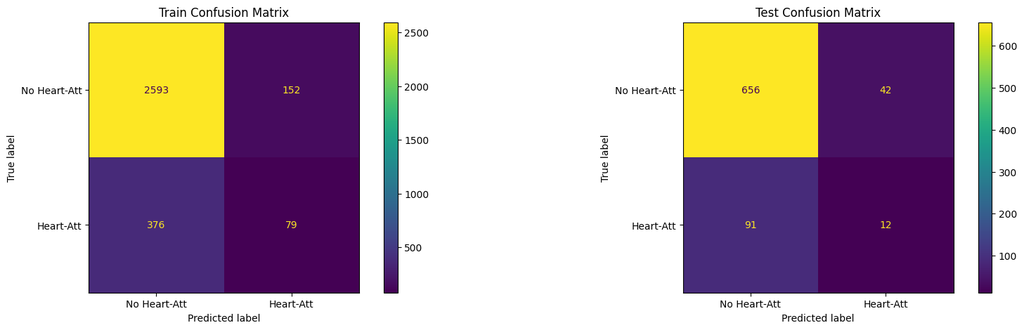

```python
# Model with irs outliers drop data
print('With IQR outliers drop data')
model_iqr, X_train_iqr, y_train_iqr, X_test_iqr, y_test_iqr = gaussian_nb_model(iqr_outliers_dataSet)
evaluate_model(model_iqr, X_train_iqr, y_train_iqr, X_test_iqr, y_test_iqr)

#  Model with zscore outliers drop data
print('With ZScore outliers drop data')
model_zc, X_train_zc, y_train_zc, X_test_zc, y_test_zc = gaussian_nb_model(zc_outliers_dataSet)
evaluate_model(model_zc, X_train_zc, y_train_zc, X_test_zc, y_test_zc)
```

As we can see with ZScore drop outliers data have more accurate Naive Bayes Model With accuracy of 83.39% and F1 score of 0.85

## Decision Tree Model

```python
def decision_tree_model(df, depth=None):
    X = df.drop(columns=['Heart-Att'])
    y = df['Heart-Att']

    X_train, X_test, y_train, y_test = train_test_split(X, y, test_size=0.2, random_state=42)
    model = tree.DecisionTreeClassifier(random_state=42, max_depth=depth)
    model.fit(X_train, y_train)

    return [model, X_train, y_train, X_test, y_test ]


def get_dt_graph(model, X):
    dot_data = StringIO()
    tree.export_graphviz(model, out_file=dot_data, filled=True, rounded=True, feature_names=X.columns, class_names=['Heart-Att', "No Heart-Att"])
    graph = pydotplus.graph_from_dot_data(dot_data.getvalue())
    return graph

# Use this fuction if user don't have graphviz installed on system
def plot_dt(model,X):
    plt.figure(figsize=(40,8))
    tree.plot_tree(model, filled=True, rounded=True, feature_names=X.columns, class_names=['Heart-Att', "No Heart-Att"])
```

```
With IQR outliers drop data
--------------------------------------------------
Train Accuracy : 0.8789962186318322
Train F1 Score: 0.9179204040472349
--------------------------------------------------
Test Accuracy : 0.8585164835164835
Test F1 Score: 0.9105562995897568
Confusion Matrix:
```

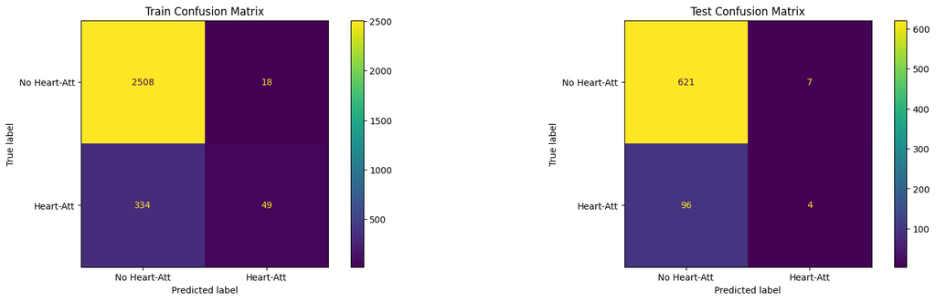

```
With ZScore outliers drop data
--------------------------------------------------
Train Accuracy : 0.868125
Train F1 Score: 0.9091411088990011
--------------------------------------------------
Test Accuracy : 0.8589263420724095
Test F1 Score: 0.9007659045015666
Confusion Matrix:
```

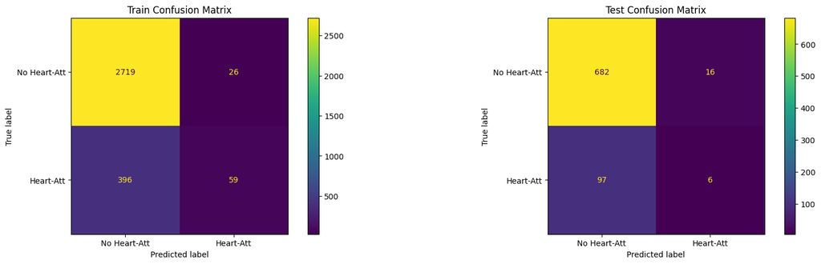

```python
# Model with irs outliers drop data
print('With IQR outliers drop data')
model_dt_iqr, X_train_dt_iqr, y_train_dt_iqr, X_test_dt_iqr, y_test_dt_iqr = decision_tree_model(iqr_outliers_dataSet,5)
evaluate_model(model_dt_iqr, X_train_dt_iqr, y_train_dt_iqr, X_test_dt_iqr, y_test_dt_iqr)

#  Model with zscore outliers drop data
print('With ZScore outliers drop data')
model_dt_zs, X_train_dt_zs, y_train_dt_zs, X_test_dt_zs, y_test_dt_sc = decision_tree_model(zc_outliers_dataSet,5)
evaluate_model(model_dt_zs, X_train_dt_zs, y_train_dt_zs, X_test_dt_zs, y_test_dt_sc)
```

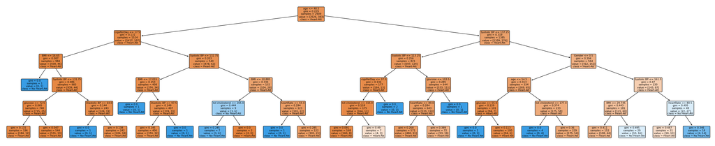

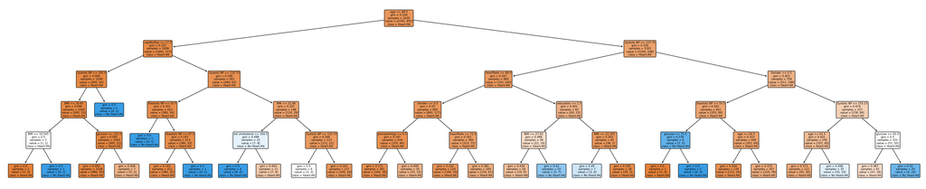

```python
plot_dt(model_dt_iqr,X_train_dt_iqr)

plot_dt(model_dt_zs,X_train_dt_zs)
```

In as we can see with both IQR drop outliers data And ZScore drop outliers date have almost same accuracy and F1 score.

We also have to compare Naive Bayes Model and Decision Tree Model but in Naive Bayes Model ZScore drop outliers data work better for further fine tuning of DT model use ZScore drop outliers data

### Hyper-parameter tuning of Decision tree

```python
# create decision tree random seeding of 42
dt = tree.DecisionTreeClassifier(random_state=42)

# Create the parameter grid based on the results of random search
params = {
    'max_depth': [2, 3, 4, 5, 8, 10, 15, 20, 30],
    'min_samples_leaf': [1,2, 5, 10, 20, 50, 100],
    'criterion': ["gini", "entropy"]
}

grid_search = GridSearchCV(estimator=dt, param_grid=params, cv=4, n_jobs=-1, verbose=1, scoring = "accuracy")
```

```python
# split data
X = zc_outliers_dataSet.drop(columns=['Heart-Att'])
y = zc_outliers_dataSet['Heart-Att']
X_train, X_test, y_train, y_test = train_test_split(X, y, test_size=0.2, random_state=42)

# fit model
grid_search.fit(X_train, y_train)
```

```
Fitting 4 folds for each of 126 candidates, totalling 504 fits
```

```
GridSearchCV(cv=4, estimator=DecisionTreeClassifier(random_state=42), n_jobs=-1,
             param_grid={'criterion': ['gini', 'entropy'],
                         'max_depth': [2, 3, 4, 5, 8, 10, 15, 20, 30],
                         'min_samples_leaf': [1, 2, 5, 10, 20, 50, 100]},
             scoring='accuracy', verbose=1)
```

```python
score_df = pd.DataFrame(grid_search.cv_results_)
score_df.head()
```

|  | mean_fit_time | std_fit_time | mean_score_time | std_score_time | param_criterion | param_max_depth | param_min_samples_leaf | params | split0_test_score | split1_test_score | split2_test_score | split3_test_score | mean_test_score | std_test_score | rank_test_score |
| --- | --- | --- | --- | --- | --- | --- | --- | --- | --- | --- | --- | --- | --- | --- | --- |
| 0 | 0.024655 | 0.007505 | 0.008130 | 0.001815 | gini | 2 | 1 | {'criterion': 'gini', 'max_depth': 2, 'min_sam... | 0.85875 | 0.8575 | 0.8575 | 0.85625 | 0.857500 | 0.000884 | 40 |
| 1 | 0.020180 | 0.004480 | 0.011967 | 0.003467 | gini | 2 | 2 | {'criterion': 'gini', 'max_depth': 2, 'min_sam... | 0.85875 | 0.8575 | 0.8575 | 0.85625 | 0.857500 | 0.000884 | 40 |
| 2 | 0.019636 | 0.003357 | 0.005244 | 0.001776 | gini | 2 | 5 | {'criterion': 'gini', 'max_depth': 2, 'min_sam... | 0.85875 | 0.8575 | 0.8575 | 0.85750 | 0.857812 | 0.000541 | 7 |
| 3 | 0.014424 | 0.004633 | 0.014170 | 0.012266 | gini | 2 | 10 | {'criterion': 'gini', 'max_depth': 2, 'min_sam... | 0.85875 | 0.8575 | 0.8575 | 0.85750 | 0.857812 | 0.000541 | 7 |
| 4 | 0.012251 | 0.000828 | 0.005499 | 0.000867 | gini | 2 | 20 | {'criterion': 'gini', 'max_depth': 2, 'min_sam... | 0.85875 | 0.8575 | 0.8575 | 0.85750 | 0.857812 | 0.000541 | 7 |

```python
score_df.nlargest(5,"mean_test_score")
```

|  | mean_fit_time | std_fit_time | mean_score_time | std_score_time | param_criterion | param_max_depth | param_min_samples_leaf | params | split0_test_score | split1_test_score | split2_test_score | split3_test_score | mean_test_score | std_test_score | rank_test_score |
| --- | --- | --- | --- | --- | --- | --- | --- | --- | --- | --- | --- | --- | --- | --- | --- |
| 9 | 0.016251 | 0.001477 | 0.006001 | 0.000707 | gini | 3 | 5 | {'criterion': 'gini', 'max_depth': 3, 'min_sam... | 0.85875 | 0.86000 | 0.85875 | 0.85875 | 0.859063 | 0.000541 | 1 |
| 18 | 0.017197 | 0.004380 | 0.005941 | 0.001545 | gini | 4 | 20 | {'criterion': 'gini', 'max_depth': 4, 'min_sam... | 0.86125 | 0.86375 | 0.85500 | 0.85625 | 0.859063 | 0.003577 | 1 |
| 10 | 0.014746 | 0.000752 | 0.008019 | 0.003945 | gini | 3 | 10 | {'criterion': 'gini', 'max_depth': 3, 'min_sam... | 0.85875 | 0.86000 | 0.85750 | 0.85750 | 0.858437 | 0.001036 | 3 |
| 17 | 0.015689 | 0.002384 | 0.005318 | 0.001906 | gini | 4 | 10 | {'criterion': 'gini', 'max_depth': 4, 'min_sam... | 0.86250 | 0.86000 | 0.85500 | 0.85625 | 0.858437 | 0.002981 | 3 |
| 8 | 0.015502 | 0.003350 | 0.005745 | 0.001478 | gini | 3 | 2 | {'criterion': 'gini', 'max_depth': 3, 'min_sam... | 0.85750 | 0.85875 | 0.85875 | 0.85750 | 0.858125 | 0.000625 | 5 |

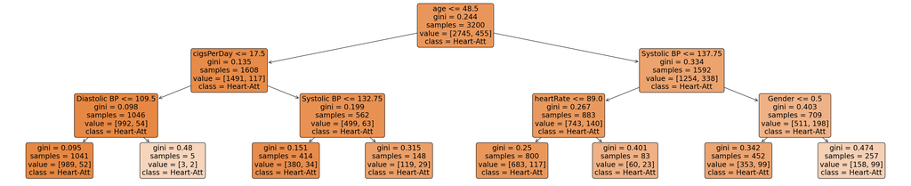

```python
plot_dt(grid_search.best_estimator_,X_train)
```

## Summary

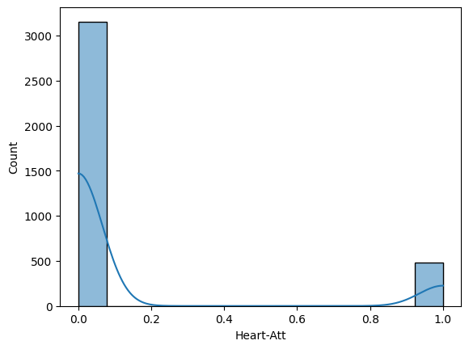

```python
sns.histplot(iqr_outliers_dataSet['Heart-Att'], kde=True)
```

So with this Data can go with GridSearchCV's best model but we can use DecisionTree max_depth=5

### Store Model with pickle as binary file

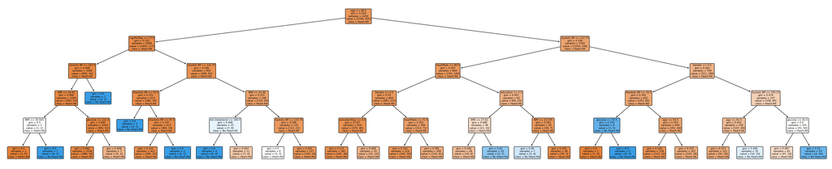

```python
pickle.dump(model_dt_zs, open('heart_model.pkl','wb'))
plot_dt(model_dt_zs,X_train_dt_zs)
```